# Projections and Decision Support

Jasper Slingsby

## Decision Support

This is probably the hardest part of the whole ecological forecasting business… people!

It is also a huge topic and not one I can cover in half a lecture. Here I just touch on a few hints and difficulties.

## Decision Support

First and foremost, *the decision at hand may not be amenable to a quantitative approach*.

- Ecological forecasting requires a *clearly defined* information need with a *measurable* (and modelable) state variable, framed within one or multiple *decision alternatives* (scenarios).
- There’s also the risk of *external factors making the forecasts unreliable*, especially if they are not controlled by the decision maker and/or their probability is unknown (e.g. fire, pandemics, etc).

## Decision Support

These external factors are where developing *scenarios with different boundary conditions can be very useful*.

- e.g. scenarios with and without a fire, or different future climate states under alternative development pathways, etc.
- Scenarios are often *“what if”* statements designed to address major sources of uncertainty that make it near-impossible to make accurate predictions with a single forecast.

## Decision Support

> It’s perhaps useful to note the distinction between *predictions *versus* projections*:
- *predictions* are statements about the probability of the occurrence of events or the state of variables in the future *based on what we currently know*
- *projections* are statements about the probability of the occurrence of events or the state of variables in the future *given specific scenarios with clear boundary conditions*

## Decision Support

### In an ideal world…

You’ll be working with an organized team that is a well-oiled machine at implementing *Adaptive Management* and *Structured Decision Making* and you can naturally slot into their workflow.

The advantages of Adaptive Management and Structured Decision Making are that they are founded on the concept of *iterative learning cycles*, which they have in common with the ecological forecasting cycle and the scientific method.

## Decision Support

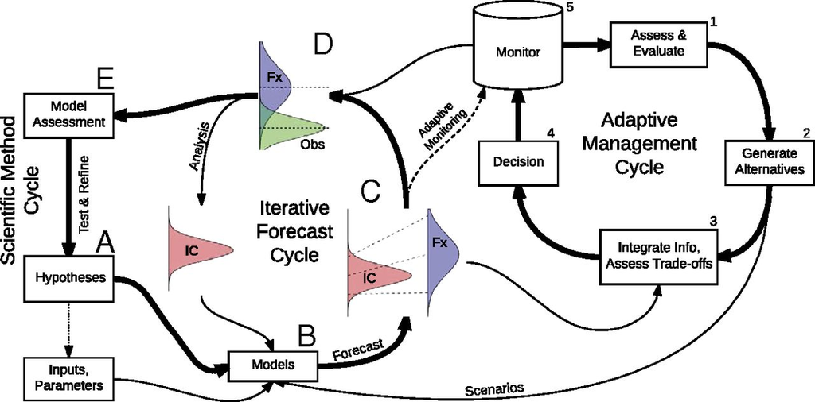

Conceptual relationships between iterative ecological forecasting, adaptive decision-making, adaptive monitoring, and the scientific method cycles (Dietze et al. 2018).

You’re already familiar with how the iterative ecological forecast cycle integrates with the Adaptive Management Cycle…

## Decision Support

The beauty for the forecaster in this scenario is that **a lot of the work is already done**.

- The decision alternatives (scenarios) have been well framed.
- The performance measures, state variables of interest and associated covariates mostly identified.
- Iterations of the learning cycle may even have already begun (through the Adaptive Management Cycle) and all you need do is *develop the existing qualitative model into something more quantitative* as more data and understanding are accumulated.

## Structured Decision Making

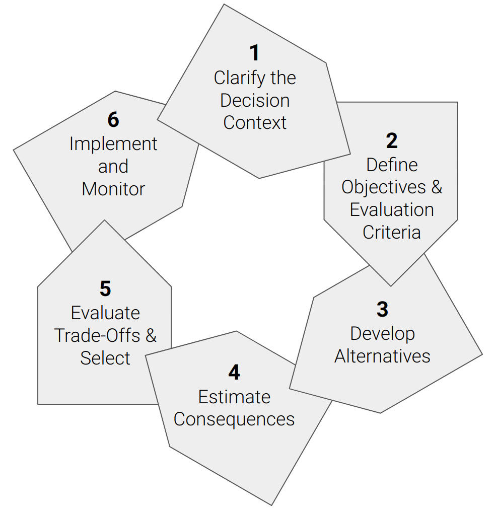

The Structured Decision Making Cycle *sensu* Gregory et al. (2012).

Focused on the process of *coming to a decision*, not the process of management, but very useful in the first iteration of the Adaptive Management Cycle.

It is valuable when there are many stakeholders with *disparate interests*.

- *decisions are ultimately about values* and often require evaluating trade-offs among properties with *incomparable units* - e.g. people housed/fed/watered vs species saved from extinction…
- this can be a highly emotive space, and greatly benefits from a structured facilitation process

## Structured Decision Making

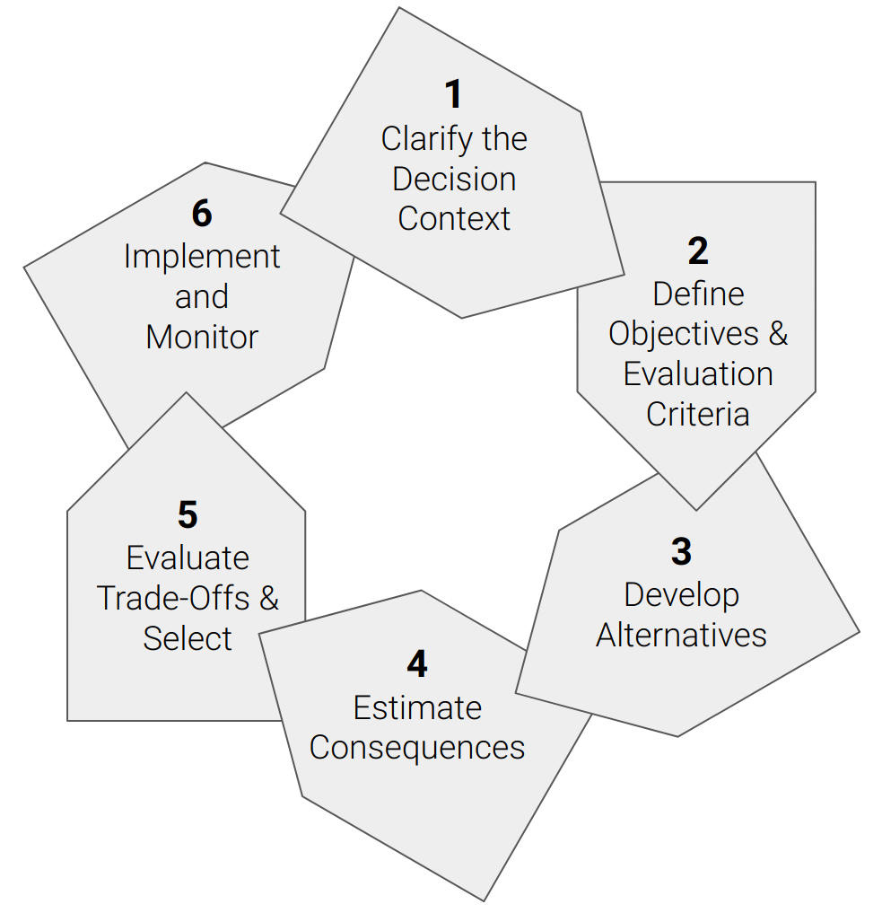

The Structured Decision Making Cycle *sensu* Gregory et al. (2012).

It tries to bring *all issues and values to light* to be considered in a transparent framework where trade-offs can be identified and considered.

- you can’t make the right choice if it isn’t on the table

It *directly addresses the social, political or cognitive biases* that marginalise some values or alternatives.

Many decisions pit people’s immediate needs (water, housing, etc) against the environment. We’d rather ignore the fact that choosing one is choosing against the other, but *if we’re not transparent about this we’re not going to learn from our decisions and improve them in the next iteration.*

## References

Dietze, Michael C, Andrew Fox, Lindsay M Beck-Johnson, Julio L Betancourt, Mevin B Hooten, Catherine S Jarnevich, Timothy H Keitt, et al. 2018. “Iterative near-term ecological forecasting: Needs, opportunities, and challenges.” *Proceedings of the National Academy of Sciences of the United States of America* 115 (7): 1424–32. https://doi.org/10.1073/pnas.1710231115.

Gregory, Robin, Lee Failing, Michael Harstone, Graham Long, Tim McDaniels, and Dan Ohlson. 2012. *Structured Decision Making: A Practical Guide to Environmental Management Choices*. John Wiley & Sons.